# chicago_crime_src

```python
import pandas as pd
import numpy as np
import scipy
import matplotlib.pyplot as plt
import datetime as dt

pd.set_option('html', False)
pd.set_option('max_columns', 35)
pd.set_option('max_rows', 200)
```

## Where did the data come from?

```python
import pandas as pd

crimes = pd.read_csv('../data/crimes_2001_to_present.csv', usecols = [1, 2, 5, 8, 13, 17, 19, 20])
```

```python
# Parse the date field
crimes['DateTime'] = crimes['Date'].map(pd.to_datetime)
crimes = crimes.drop('Date', axis = 1)

# Only consider data from 2004 (the last 10 years)
crimes = crimes[crimes['DateTime'] >= dt.datetime(2004, 1, 1)]

# Clean up community area field
crimes['Community Area'] = crimes['Community Area'].map(lambda x:
                                                        int(x) if not (pd.isnull(x) or x == ' ') else 0)
crimes = crimes[crimes['Community Area'] != 0]
```

The crimes data was downloaded from the Chicago data portal, covering incidences of crime from 2001, and contains over 5.5 million records.

```python
import pandas as pd

# The demographics table was obtained by analyzing the 2010 census data for the city of Chicago.
# census data for age and sex for different races
demo = {}
for d in ['P12', 'P12I', 'P12H', 'P12B', 'P12D']:
    df = pd.read_csv('../data/DEC_10_SF1_' + d + '_with_ann.csv', header = 1)
    demo[d] = df[df['Geography'] == 'Chicago city, Illinois']

group_names = ['Under 5', '5 to 14', '15 to 24', '25 to 34', '35 to 44', '45 to 54',
               '55 to 64', 'Over 65', 'Total']

# Regroup the census data into the above age groups
def group_ages(s):
    age_groups = []
    age_groups.append(s[1])
    age_groups.append(s[2:4].sum())
    age_groups.append(s[4:9].sum())
    age_groups.append(s[9:11].sum())
    age_groups.append(s[11:13].sum())
    age_groups.append(s[13:15].sum())
    age_groups.append(s[15:18].sum())
    age_groups.append(s[18:].sum())
    age_groups.append(s[0])
    return age_groups

P12_R = pd.DataFrame({'Male': group_ages(demo['P12'].ix[:, 4:28].stack()),
                      'Female': group_ages(demo['P12'].ix[:, 28:].stack())}, index = group_names)
P12IH_R = pd.DataFrame({'Male': [sum(x) for x in zip(group_ages(demo['P12I'].ix[:, 4:28].stack()),
                                                     group_ages(demo['P12H'].ix[:, 4:28].stack()))],
                        'Female': [sum(x) for x in zip(group_ages(demo['P12I'].ix[:, 28:].stack()),
                                                       group_ages(demo['P12H'].ix[:, 28:].stack()))]},
                       index = group_names)
P12B_R = pd.DataFrame({'Male': group_ages(demo['P12B'].ix[:, 4:28].stack()),
                       'Female': group_ages(demo['P12B'].ix[:, 28:].stack())}, index = group_names)
P12D_R = pd.DataFrame({'Male': group_ages(demo['P12D'].ix[:, 4:28].stack()),
                       'Female': group_ages(demo['P12B'].ix[:, 28:].stack())}, index = group_names)

demographics = pd.concat([P12_R, P12IH_R, P12B_R, P12D_R], axis = 0,
                         keys = ['ALL', 'WHITE', 'AFAM', 'ASIAN'])
```

```python
from pandas.io.excel import read_excel

# The demographics by community area data was downloaded from
# http://robparal.blogspot.com/2012/05/hard-to-find-census-data-on-chicago.html
names = ['Community Area', 'Neighborhood', 'NHW', 'AFAM', 'ASIAN', 'HISP', 'Total']

census = {}
census[2000] = read_excel('../data/Race_by_Community_Area_2000_2010.xlsx', skiprows = [0, 1, 2, 3, 4],
                           parse_cols = 'A:D, F, H, J', names = names, header = None, skip_footer = 10,
                           index_col = 'Community Area')
census[2010] = read_excel('../data/Race_by_Community_Area_2000_2010.xlsx', skiprows = [0, 1, 2, 3, 4],
                           parse_cols = 'L:O, Q, S, U', names = names, header = None, skip_footer = 10,
                           index_col = 'Community Area')

comm_area = pd.read_csv('../data/CommAreas.csv', usecols = [4, 5, 7], index_col = 'AREA_NUMBE').sort_index()

for _, v in census.iteritems():
    # sum NHW and HISP columns into WHITE
    v['White'] = v['NHW'] + v['HISP']

    # include population density field
    # convert sq ft into sq mi
    v['Population Density'] = v['Total'].astype(float)/comm_area['SHAPE_AREA']*27878400
    v.drop('TOTAL', axis = 0, inplace = True)
```

The demographics table was obtained by analyzing the 2010 census data for the city of Chicago. It tabulates the population grouped into age brackets and sex. The tables referenced are DEC_10_SF1_P12_with_ann.csv, DEC_10_SF1_P12B_with_ann.csv, DEC_10_SF1_P12D_with_ann.csv, DEC_10_SF1_P12H_with_ann.csv, and DEC_10_SF1_P12I_with_ann.csv.

The census data that gives the demographics of Chicago community areas was downloaded from http://robparal.blogspot.com/2012/05/hard-to-find-census-data-on-chicago.html.

The total land area of community areas was downloaded from the chicago data portal.

```python
import dateutil.parser

def date_parser(date_str, time_str):
    if pd.isnull(time_str):
        time_str = ' '
    return dateutil.parser.parse(' '.join([date_str, time_str]))

names = ['Address', 'Date', 'Time', 'Location', 'Neighborhood', 'Age', 'Gender',
         'Race', 'Name', 'Cause', 'Story URL', 'Case Number', 'Charges and Trials']

hom = {}
for y in range(2007, 2014):
    hom[y] = pd.read_csv('../data/homicides_' + str(y) + '.csv', parse_dates= [['Date', 'Time']],
                          date_parser = date_parser, skiprows = 1, names = names)

homicides = pd.concat(hom.values(), axis = 0)
homicides['Year'] = homicides['Date_Time'].map(lambda x: x.year)

# process 'Age' field into a numeric 'Age_R' field.
def get_age(age_str):
    if pd.isnull(age_str): return None
    if age_str == 'Newborn':
        return 0
    elif ('day' in age_str) or ('week' in age_str) or ('month' in age_str):
        return 0
    elif '20s' in age_str:
        return 25
    elif '30s' in age_str:
        return 35
    else:
        return int(age_str)

homicides['Age_R'] = homicides['Age'].map(get_age)

age_groups = ['Under 5', '5 to 14', '15 to 24', '25 to 34', '35 to 44', '45 to 54',
              '55 to 64', 'Over 65']
ages = [0, 5, 15, 25, 35, 45, 55, 65, 100]

homicides['Age Group'] = pd.cut(homicides['Age_R'], ages, right = False, labels = age_groups)
homicides = homicides.drop('Age_R', axis = 1)
```

The homicides data were downloaded from the redeye Chicago homicide tracker website, http://homicides.redeyechicago.com/. The dataset includes 100 more homicides over the period 2007-2013 than the dataset from the Chicago data portal, and includes demographic information on the victims.

`*`In aggregating the murders into victim's age groups, there are 64 datapoints with missing ages. Those indicated 'unknown: 20s' (3 datapoints) and 'unknown: 30s' (1 datapoint) were reclassified as being of age 25 and 35, respectively.

## Analyzing Murders in Chicago

### Total murders each year per 100,000 people in Chicago.

```python
import numpy as np
from scipy.interpolate import InterpolatedUnivariateSpline

# Interpolate the population linearly between 2000 and 2010
yr = np.linspace(2001, 2010, 2)
pop = np.array([census[2000]['Total'].sum(), census[2010]['Total'].sum()])

s = InterpolatedUnivariateSpline(yr, pop, k = 1)
population = map(round, s(np.linspace(2001, 2013, 13)))

# The number of murders per 100000 people per year in Chicago
homicides_by_year = homicides.groupby('Year').size()
homicides_by_year = homicides_by_year/population[6:]*100000
```

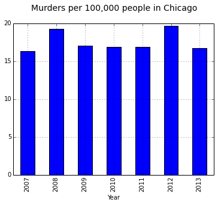

```python
homicides_by_year.plot(kind = 'bar', figsize = (6, 5))
plt.title('Murders per 100,000 people in Chicago\n', fontsize = 14)
plt.subplots_adjust(top = 0.85, bottom = 0.15)
plt.savefig('../figs/murders.png')
```

The rate of murder per 100,000 people in Chicago between 2007 and 2013 has been broadly consistent at around 17, but with peaks in 2008 and 2012 reaching almost 20. For comparison, the murder rate is 4.7 in the U.S. as a whole (2011), 6.3 in New York City (2011), and 7.8 in Los Angeles (2012).

`*`The population of Chicago for each year was obtained by linearly interpolating between the populations at 2000 and 2010.

### Murder rates by race, gender and age

```python
# Clean up the race field
homicides['Race'] = homicides['Race'].str.rstrip().str.upper()
homicides.replace('BLACK', 'AFAM', inplace = True)

# Consider the year 2013
homicides13 = homicides[homicides['Year']==2013]

# The number of murders by race of victim
race = homicides13.groupby(['Race']).size()

pop = pd.Series([demographics.ix[('ASIAN', 'Total'), ].sum(),
                 demographics.ix[('AFAM', 'Total'), ].sum(),
                 demographics.ix[('WHITE', 'Total'), ].sum()], index = ['ASIAN', 'AFAM', 'WHITE'])

race = race/pop*100000
race.index.name = None

# The number of murders by race and gender of victim
gender = homicides13.groupby(['Race', 'Gender']).size()

pop_gender = pd.concat([demographics.ix[('ASIAN', 'Total'), ],
                        demographics.ix[('AFAM', 'Total'), ],
                        demographics.ix[('WHITE', 'Total'), ]], keys = ['ASIAN', 'AFAM', 'WHITE'])
pop_gender.index.names = ['Race', 'Gender']

gender = (gender/pop_gender*100000).unstack('Gender')
gender.columns.name = None
gender.index.name = None

# The number of murders by race and age of victim
age = homicides13.groupby(['Race', 'Age Group']).size()

pop_age = pd.concat([demographics.ix[('ASIAN', ), ].sum(1)[:-1],
                     demographics.ix[('AFAM', ), ].sum(1)[:-1],
                     demographics.ix[('WHITE', ), ].sum(1)[:-1]], keys = ['ASIAN', 'AFAM', 'WHITE'])
pop_age.index.names = ['Race', 'Age Group']

age = (age/pop_age*100000).fillna(0).unstack()
age.columns.name = None
cols = ['Under 5', '5 to 14', '15 to 24', '25 to 34', '35 to 44', '45 to 54', '55 to 64', 'Over 65']
age = age[cols]
age.index.name = None

# Coverage of murders in the media
media = (pd.isnull(homicides['Story URL'])) | (pd.isnull(homicides['Charges and Trials']))
coverage = homicides[~media].groupby(['Race']).size()/race
coverage.index.name = None
```

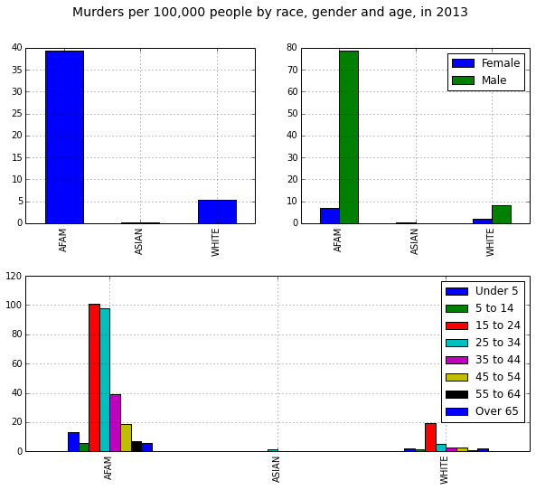

```python
fig = plt.figure(figsize = (10, 8))

ax1 = plt.subplot2grid((2, 2), (0, 0))
ax2 = plt.subplot2grid((2, 2), (0, 1))
ax3 = plt.subplot2grid((2, 2), (1, 0), colspan = 2)
race.plot(ax = ax1, kind = 'bar')
gender.plot(ax = ax2, kind = 'bar')
age.plot(ax = ax3, kind = 'bar')
ax3.legend(loc='best')
plt.subplots_adjust(hspace = 0.3)
fig.suptitle('Murders per 100,000 people by race, gender and age, in 2013', fontsize = 14)

plt.savefig('../figs/murders_grouped.png')
```

Gunshot is the main cause of homicides by far, with stabbing coming second. The homicide victims are overwhemingly African American men: almost 80 out of every 100,000 African American men in Chicago are murdered each year, while the rate for white men is around 10 out of every 100,000. The rate for African American women is a tenth of that for African American men (about 8 per 100,000) and that for white women is 2 per every 100,000. For both men and women, the proportion of murders from gunshot wounds is higher for blacks than for whites.

African American men between 15 and 24 of age is the most vulnerable group. Over 100 out of every 100,000 African American men in this age group gets murdered each year, 98% from gunshot wounds. Together, African American men of ages beteen 15 and 34 make up 56% of the total murder victims in Chicago.

`*`There were 32 and 112 datapoints with missing values for cause and race, respectively, out of 3312 datapoints total, which were ignored. `**` The demographics of 2010 was used.

```python
# The data of socioeconomic indicators for communitiy areas was obtained from the Chicago data portal.
# Join with socioeconomic indicators
names = ['Community Area', 'Neighborhood', 'Per Capita Income']
socioeconomic = pd.read_csv('../data/socioeconomic_indicators_2007_to_2011.csv', usecols = [0, 1, 7],
                            skiprows = 1, names = names)

# Drop the last(Chicago) row
socioeconomic.drop(77, axis = 0, inplace = True)
```

```python
# Clean up neighborhood field
homicides = homicides.replace('North\xc2\xa0Lawndale', 'North Lawndale')
homicides = homicides.replace('Lakeview', 'Lake View')

neighborhoods = pd.DataFrame(homicides13.groupby('Neighborhood').size(),
                             columns = ['Homicides'])
neighborhoods = pd.merge(neighborhoods, census[2010][['Neighborhood', 'AFAM', 'Total']],
                         left_index = True, right_on = 'Neighborhood', how = 'outer').fillna(0).reset_index()
neighborhoods = pd.merge(neighborhoods, socioeconomic[['Community Area', 'Per Capita Income']],
                         on = 'Community Area').set_index('Neighborhood')
neighborhoods.sort(columns = 'Homicides', inplace = True)
neighborhoods.index.name = None
```

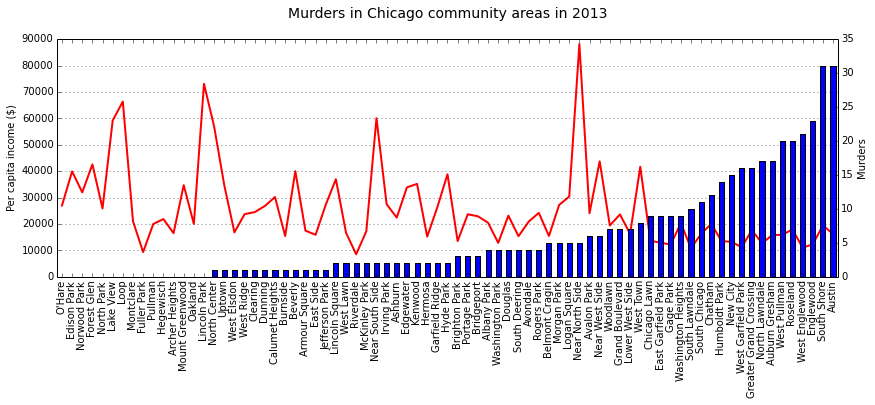

```python
fig = plt.figure(figsize = (14, 6))
ax1 = fig.add_subplot(111)
neighborhoods['Per Capita Income'].plot(ax = ax1, color = 'red', linewidth = 2)
ax2 = ax1.twinx()
neighborhoods['Homicides'].plot(ax = ax2, kind = 'bar')

ax1.get_xaxis().set_visible(False)
ax2.get_xaxis().set_visible(True)
ax2.grid()
ax1.set_ylabel('Per capita income ($)')
ax2.set_ylabel('Murders')

plt.title('Murders in Chicago community areas in 2013\n', fontsize = 14)
plt.subplots_adjust(top = 0.85, bottom = 0.3)
plt.savefig('../figs/murders_ca.png')
```

The city of Chicago is divided into 77 community areas. Murders are strongly segregated by community: 15% of total murders that occurred in Chicago in 2013 were in just two community areas, Austin and South Shore. These two communities account for only 5.5% of the total population of Chicago. The 10 communities with the highest number of murders together make up 48% of the total murders in Chicago in 2013, while having 16% of the population. The plot shows that the communities with the highest number of murders are also those that have the lowest income.

### Which murders are covered in the media?

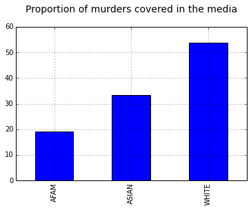

```python
coverage.plot(kind = 'bar')
plt.title('Proportion of murders covered in the media\n', fontsize = 14)
```

## Overall Trends in Crime

```python
#crimes_data = crimes.copy()
crimes_data = crimes[crimes['Year'] < 2014]

# Divide the crimes into categories of violent, property, drug, and other.
Violent_Crime = ['HOMICIDE', 'CRIM SEXUAL ASSAULT', 'ASSAULT', 'BATTERY', 'ROBBERY']
Property_Crime = ['THEFT', 'BURGLARY', 'CRIMINAL DAMAGE', 'MOTOR VEHICLE THEFT', 'ARSON']
Drug_Crime = ['NARCOTICS']

def get_category(type):
    if type in Violent_Crime:
        return 'VIOLENT'
    elif type in Property_Crime:
        return 'PROPERTY'
    elif type in Drug_Crime:
        return 'DRUG'
    else:
        return 'OTHER'

crimes_data['Category'] = crimes_data['Primary Type'].apply(get_category)

# The population of each year is interpolated between the populations of 2000 and 2010
from scipy.interpolate import InterpolatedUnivariateSpline

yr = np.linspace(2001, 2010, 2)
pop = np.array([census[2000]['Total'].sum(), census[2010]['Total'].sum()])

s = InterpolatedUnivariateSpline(yr, pop, k = 1)
population = map(round, s(np.linspace(2001, 2013, 13)))

# Group the crimes into categories
crimes_category = crimes_data.groupby(['Year', 'Category']).size()
crimes_category = crimes_category.unstack('Category')
crimes_category['TOTAL'] = crimes_category.sum(axis = 1)

# Normalize by population
crimes_category = crimes_category.div(population[3:], axis = 0)
crimes_category.index = crimes_category.index.map(str)
crimes_category.index.name = 'Year'
crimes_category.columns.name = None

# The proportions of property, violent and drug crimes
crimes_proportion = pd.DataFrame()
for col in ['PROPERTY', 'VIOLENT', 'DRUG', 'OTHER']:
    crimes_proportion[col] = crimes_category[col]/crimes_category['TOTAL']
crimes_proportion.index = crimes_proportion.index.map(str)
crimes_proportion.index.name = 'Year'
```

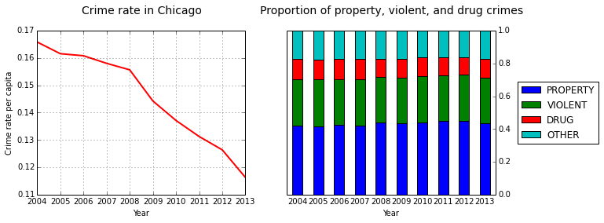

```python
fig = plt.figure(figsize = (12, 4))
ax1 = fig.add_subplot(1, 2, 1)
crimes_category[['TOTAL']].plot(ax = ax1, color = 'red', linewidth = 2)
ax2 = fig.add_subplot(1, 2, 2)
crimes_proportion.plot(ax = ax2, kind = 'bar', stacked = True, secondary_y = True, ylim = [0, 1])

ax1.set_ylabel('Crime rate per capita')
ax1.legend().set_visible(False)
ax2.set_xlabel('Year')
ax1.set_title('Crime rate in Chicago\n', fontsize = 14)
ax2.set_title('Proportion of property, violent, and drug crimes\n', fontsize = 14)
plt.legend(loc = 'center right', bbox_to_anchor=(1.52, 0.5))
plt.subplots_adjust(top = 0.85, right = 0.8)
fig.savefig('../figs/crimes.png')
```

The overall crime rate in Chicago has been steady decreasing between the years 2004 and 2013. The proportions of property, violent, and drug crimes are broadly constant over the years, although the proportion of property crimes has increased slightly since 2008 while the proportion of drug crimes has decreased.

Violent crimes are are those committed directly against a person: homicide, criminal sexual assault, robbery, and aggravated assault/battery. Property crimes are those in which there is no direct threat or harm to a person - burglary, theft, motor vehicle theft, criminal damage, and arson.

```python
crimes_type = crimes_data.groupby(['Year', 'Primary Type']).size().unstack('Primary Type').fillna(0)
crimes_type['TOTAL'] = crimes_type.sum(axis = 1)

# Combine assault and battery
crimes_type['ASSAULT/BATTERY'] = crimes_type['ASSAULT'] + crimes_type['BATTERY']
crimes_type.drop(['ASSAULT', 'BATTERY'], axis = 1, inplace = True)

# Combine criminal damage and criminal trespass
crimes_type['CRIMINAL DAMAGE/TRESPASS'] = crimes_type['CRIMINAL DAMAGE'] + crimes_type['CRIMINAL TRESPASS']
crimes_type.drop(['CRIMINAL DAMAGE', 'CRIMINAL TRESPASS'], axis = 1, inplace = True)

# Rename deceptive practice fraud
crimes_type.rename(columns = {'DECEPTIVE PRACTICE': 'FRAUD'}, inplace = True)

# Drop crime types with less than 10000 occurrences in every year except homicides, and other offense
drop = ((crimes_type < 10000).all(axis = 0)) & ~(crimes_type.columns == 'HOMICIDE') | \
       (crimes_type.columns == 'OTHER OFFENSE')
crimes_type.drop(crimes_type.columns[drop], axis = 1, inplace = True)

# Normalize by population
crimes_type = crimes_type.div(population[3:], axis = 0)

crimes_type.ix[2004].argsort()
crimes_type = crimes_type.reindex_axis(crimes_type.sum().order(ascending = False).index, axis = 1)

# Change in crime between 2004 and 2013
initial = crimes_type.ix[2004, 1:]
current = crimes_type.ix[2013, 1:]
change = (current - initial)/initial*100
change = change[~change.isnull()]
change.index.name = None

initial_cat = crimes_category.ix['2004', ]
current_cat = crimes_category.ix['2013', ]
change_cat = (current_cat - initial_cat)/initial_cat*100
change_cat = change_cat[~change_cat.isnull()]
```

Assault and battery have been combined in the following, although they are separate crime types in the dataset. An assault is an attempt or threat to injure another person, while a battery would be actually contacting another person in a harmful or offensive manner. Similarly, criminal damage and criminal trespass have also been combined.

Deceptive practice has been renamed Fraud.

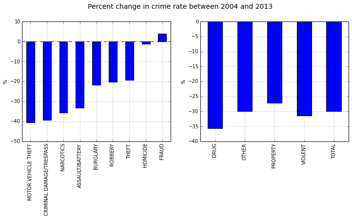

```python
fig = plt.figure(figsize = (12, 6.5))
ax1 = fig.add_subplot(1, 2, 1)
change.order().plot(ax = ax1, kind = 'bar')
ax1.set_xlabel = None
ax1.set_ylabel('%')
ax2 = fig.add_subplot(1, 2, 2)
change_cat.plot(ax = ax2, kind = 'bar')
ax2.set_ylabel('%')
plt.suptitle('Percent change in crime rate between 2004 and 2013\n', fontsize = 14)
plt.subplots_adjust(bottom = 0.375)
fig.savefig('../figs/crimes_change.png')
```

Drug and violent crime rates have decreased the most while property crimes rates decresed the least between 2004 and 2013.

`*`The population of Chicago for each year was obtained by linearly interpolating between the populations at 2000 and 2010.

### Which areas have the highest/lowest occurrence of crime per capita?

```python
# Which areas had the highest/lowest occurrence of crime in 2013?
area = crimes_data[crimes_data['Year'] == 2013].groupby('Community Area').size()
crimes_area = pd.DataFrame(area/census[2010]['Total'], columns = ['Crimes'])

# Join with socioeconomic data
crimes_area = pd.merge(crimes_area, socioeconomic, left_index = True,
                        right_on = 'Community Area').set_index('Neighborhood')
crimes_area.sort(columns = 'Crimes', inplace = True)
crimes_area.index.name = None
```

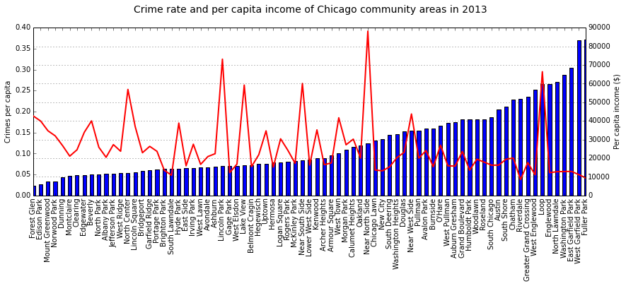

```python
fig = plt.figure(figsize = (14, 6))
ax1 = fig.add_subplot(111)
crimes_area['Crimes'].plot(ax = ax1, kind = 'bar')
ax2 = ax1.twinx()
crimes_area['Per Capita Income'].plot(ax = ax2, color = 'red', linewidth = 2)
ax1.grid()
ax1.set_ylabel('Crimes per capita')
ax2.set_ylabel('Per capita income ($)')
plt.title('Crime rate and per capita income of Chicago community areas in 2013\n', fontsize = 14)
plt.subplots_adjust(top = 0.85, bottom = 0.3)
plt.savefig('../figs/crimes_area.png')
```

Overall crime rate tends to increase with decreasing income, but there are some areas with high income (peaks in the per capita income curve) that have high crimes rates. The types of crimes that occur gives some idea why.

`*`The data for the per capita income of Chicago community areas was downloaded from the Chicago data portal.

### Which crimes tend to occur in certain areas?

```python
crimes_category_area = crimes_data[crimes_data['Year'] == 2013].groupby(['Community Area', 'Category']).size().unstack()
crimes_category_area = crimes_category_area.reindex_axis(['PROPERTY', 'VIOLENT', 'DRUG', 'OTHER'], axis = 1)
crimes_category_area['TOTAL'] = crimes_category_area.sum(axis = 1)
crimes_category_area = crimes_category_area.div(census[2010]['Total'], axis = 0)

# Find proportion of property, violent and drug crimes in the community areas
crimes_category_area = pd.merge(crimes_category_area, socioeconomic, left_index = True,
                                right_on = 'Community Area').set_index('Neighborhood')

crimes_category_area['P PROPERTY'] = crimes_category_area['PROPERTY']/crimes_category_area['TOTAL']
crimes_category_area['P VIOLENT'] = crimes_category_area['VIOLENT']/crimes_category_area['TOTAL']
crimes_category_area['P DRUG'] = crimes_category_area['DRUG']/crimes_category_area['TOTAL']
crimes_category_area.sort(columns = 'TOTAL', inplace = True)
crimes_category_area.index.name = None
```

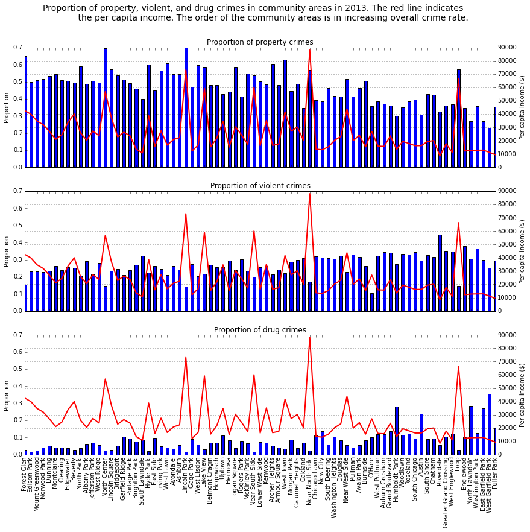

```python
fig, axes = plt.subplots(3, 1, figsize = (14, 12.5), sharex = True, sharey = True)

crimes_category_area['P PROPERTY'].plot(ax = axes[0], kind = 'bar')
ax0 = axes[0].twinx()
crimes_category_area['Per Capita Income'].plot(ax = ax0, color = 'red', linewidth = 2)

axes[0].grid()
axes[0].set_title('Proportion of property crimes')
axes[0].set_ylabel('Proportion')
ax0.set_ylabel('Per capita income ($)')
axes[0].set_ylim([0, 0.7])

crimes_category_area['P VIOLENT'].plot(ax = axes[1], kind = 'bar')
ax1 = axes[1].twinx()
crimes_category_area['Per Capita Income'].plot(ax = ax1, color = 'red', linewidth = 2)
ax1.set_ylabel('Per capita income ($)')

axes[1].grid()
axes[1].set_title('Proportion of violent crimes')
axes[1].set_ylabel('Proportion')

crimes_category_area['P DRUG'].plot(ax = axes[2], kind = 'bar')
ax2 = axes[2].twinx()
crimes_category_area['Per Capita Income'].plot(ax = ax2, color = 'red', linewidth = 2)

axes[2].grid()
axes[2].set_title('Proportion of drug crimes')
axes[2].set_ylabel('Proportion')
ax2.set_ylabel('Per capita income ($)')

plt.suptitle('Proportion of property, violent, and drug crimes in community areas in 2013. The red line indicates \n \
              the per capita income. The order of the community areas is in increasing overall crime rate.',
             fontsize = 14)
plt.subplots_adjust(bottom = 0.15)
plt.savefig('../figs/crimes_area_grouped.png')
```

```python
import scipy.stats

cor = scipy.stats.spearmanr(crimes_category_area[['PROPERTY', 'VIOLENT', 'DRUG', 'TOTAL', 'Per Capita Income']])
print cor[0][4]

cor_p = scipy.stats.spearmanr(crimes_category_area[['P PROPERTY', 'P VIOLENT', 'P DRUG', 'TOTAL', 'Per Capita Income']])
print cor_p[0][4]
```

```
[-0.36807929 -0.61698827 -0.67372102 -0.50118303  1.        ]
[ 0.66433566 -0.65476629 -0.70957989 -0.50118303  1.        ]
```

The plots indicate that the proportion of property crimes tends to increase with income, while the proportions of violent and drug crimes decrease with increasing income. This is corroborated by considering the Spearman's rank correlation coefficient between per capita income and proportion of a particular type of crime. The coefficient measures how well the relationship between two variables can be described using a monotonic function. A value of 1 or -1 indicates each of the variables is a perfect monotonically increasing or decreasing function of the other. The coefficients are 0.66, -0.65, and -0.71, respectively, for the correlation between per capita income vs. proportion of property, violent, and drug crimes.

### Which types of crimes have the highest arrest rate?

```python
# Which types of crime have the highest arrest area?
arrest_rate = crimes_data[crimes_data['Year'] == 2013].groupby(['Category', 'Arrest']).size().unstack('Arrest')
arrest_rate.columns = ['False', 'True']
arrest_rate = arrest_rate.reindex_axis(['PROPERTY', 'VIOLENT', 'DRUG', 'OTHER'], axis = 0)
arrest_rate = arrest_rate.reindex_axis(['True', 'False'], axis = 1)

arrest_rate['Arrest Rate'] = arrest_rate['True']/arrest_rate.sum(axis = 1)
```

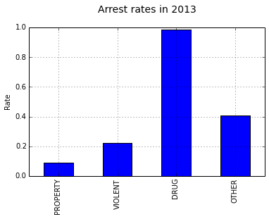

```python
arrest_rate['Arrest Rate'].plot(kind = 'bar', figsize = (6, 4.5))
plt.title('Arrest rates in 2013\n', fontsize = 14)
plt.ylabel('Rate')
plt.subplots_adjust(bottom = 0.2, top = 0.85)
plt.savefig('../figs/arrest.png')
```

Arrest rates in general are pretty low, about 20% for violent crimes and 9% for property crimes. The exception is drug crime, where the arrest rate is close to 100%. This is due to the nature of drug crime, which is rarely reported.

### Which neighborhoods have the highest/lowest arrest rate?

```python
#Which areas have the highest/lowest arrest rate?

def get_arrest_rate(df):
    arr = df.groupby(['Community Area', 'Arrest']).size().unstack()
    arr.columns = ['False', 'True']
    arr['Rate'] = arr['True']/arr.sum(axis = 1)
    arr = pd.merge(arr, socioeconomic, left_index = True,
                   right_on = 'Community Area').set_index('Neighborhood')
    arr['Crimes'] = crimes_category_area['TOTAL']
    arr.index.name = None
    arr.sort(columns = 'Crimes', inplace = True)
    return arr

arrest_area = get_arrest_rate(crimes_data[crimes_data['Year'] == 2013])
```

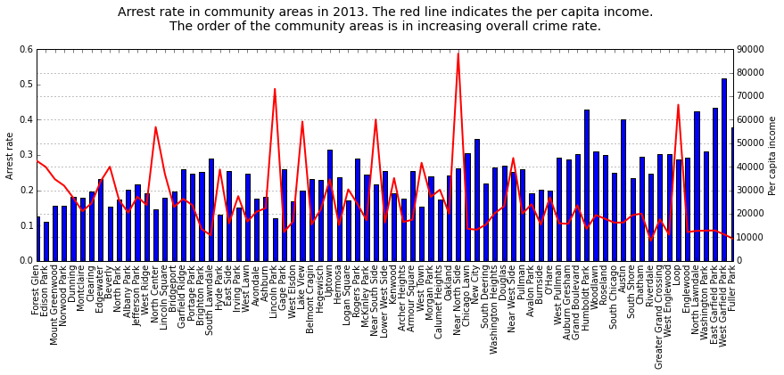

```python
fig = plt.figure(figsize = (14, 6))
ax0 = fig.add_subplot(111)
arrest_area['Rate'].plot(ax = ax0, kind = 'bar')
ax1 = ax0.twinx()
arrest_area['Per Capita Income'].plot(ax = ax1, color = 'red', linewidth = 2)

ax0.grid()
ax0.set_ylabel('Arrest rate')
ax1.set_ylabel('Per capita income')

plt.title('Arrest rate in community areas in 2013. The red line indicates the per capita income. \
           \nThe order of the community areas is in increasing overall crime rate.\n', fontsize = 14)
plt.subplots_adjust(top = 0.85, bottom = 0.3)
plt.savefig('../figs/arrest_grouped.png')
```

```python
print scipy.stats.spearmanr(arrest_area[['Rate', 'Crimes', 'Per Capita Income']])[0]
```

```
[[ 1.          0.70721384 -0.61953836]
 [ 0.70721384  1.         -0.50118303]
 [-0.61953836 -0.50118303  1.        ]]
```

The neighborhoods with more crime tends to have higher arrest rates, with a spearman's rank correlation coefficient of 0.71. The income level has a negative correlation with the arrest rate, probably due to the fact that high income communities have less crime. But is the larger proportion of drug crimes in less affluent communities skewing the results? I consider the arrest rate of non-drug crimes below to answer this question.

```python
# What about arrest rates on non-drug crimes?
crimes13 = crimes_data[crimes_data['Year'] == 2013]
arrest_area_ndrug = get_arrest_rate(crimes13[crimes13['Category'] != 'DRUG'])
```

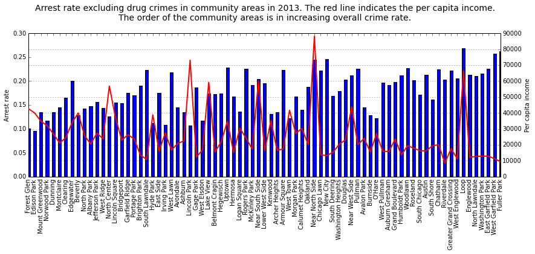

```python
fig = plt.figure(figsize = (14, 6))
ax0 = fig.add_subplot(111)
arrest_area_ndrug['Rate'].plot(ax = ax0, kind = 'bar')
ax1 = ax0.twinx()
arrest_area_ndrug['Per Capita Income'].plot(ax = ax1, color = 'red', linewidth = 2)

ax0.grid()
ax0.set_ylabel('Arrest rate')
ax1.set_ylabel('Per capita income')

plt.title('Arrest rate excluding drug crimes in community areas in 2013. The red line indicates the per capita income. \
           \nThe order of the community areas is in increasing overall crime rate.\n', fontsize = 14)
plt.subplots_adjust(top = 0.85, bottom = 0.3)
plt.savefig('../figs/arrest_grouped_ndrug.png')
```

```python
print scipy.stats.spearmanr(arrest_area_ndrug[['Rate', 'Crimes', 'Per Capita Income']])[0]
```

```
[[ 1.          0.60571008 -0.45714812]
 [ 0.60571008  1.         -0.50118303]
 [-0.45714812 -0.50118303  1.        ]]
```

The rank correlation coefficient of non-drug crimes and arrest rate is 0.6, definitely smaller than that for all crimes, but still indicative that more arrests occurr in neighborhoods with more crimes, even when drug crimes are excluded. There is a smaller negative rank correlation between arrest rate and income when drug crimes are excluded.

### Crime Prediction

```python
crimes_pred = crimes.copy()
crimes_pred['Date'] = crimes_pred['DateTime'].map(lambda x: x.date())

times = [0, 8, 16, 24]
shifts = ['0', '1', '2'] # shift 0: 00 to 08, shift 1: 08 to 16, shift 2: 16 to 00
crimes_pred['Shift'] = pd.cut(crimes_pred['DateTime'].map(lambda x: x.hour), times, right = False, labels = shifts)

days = ['MON', 'TUE', 'WED', 'THU', 'FRI', 'SAT', 'SUN']
crimes_pred['Day of Week'] = crimes_pred['DateTime'].map(lambda x: days[x.weekday()])
```

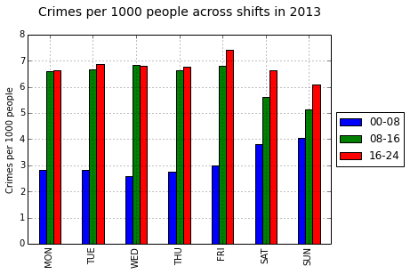

```python
total_population = census[2010]['Total'].sum().astype(float)
crimes_trend = crimes_pred[crimes_pred['Year'] == 2013].groupby(['Day of Week', 'Shift']).size().unstack()\
               /total_population*1000
crimes_trend = crimes_trend.loc[['MON', 'TUE', 'WED', 'THU', 'FRI', 'SAT', 'SUN']]
crimes_trend.rename(columns = {'0': '00-08', '1': '08-16', '2': '16-24'}, inplace = True)
crimes_trend.columns.name = 'SHIFT'

crimes_trend.plot(kind = 'bar', figsize = (7, 4.5))
plt.title('Crimes per 1000 people across shifts in 2013\n', fontsize = 14)
plt.ylabel('Crimes per 1000 people')
plt.legend(loc = 'center left', bbox_to_anchor =(1, 0.5))
plt.subplots_adjust(right = 0.8, top = 0.85)
plt.savefig('../figs/crimes_trend.png')
```

Dividing each day into three 8-hour shifts that closely follow actual police shifts, I consider the variation of crime rate on day of week and time of day. The week divides into 21 shifts, and the above plot shows that there is a clear pattern of crime rate being higher during the evening hours, and on weekends. Crimes rates are highest on Friday evenings. During the night (between midnight and 8 am), crime rates are highest on Saturdays and Sundays; however, crimes rates are lowest on those days between 8 am and midnight.

```python
# Group crimes by date, day of week, shift and community area.
crimes_grouped = pd.DataFrame(crimes_pred.groupby(['Date', 'Day of Week', 'Shift', 'Community Area']).size(),
                              columns = ['Crimes']).fillna(0).reset_index()
crimes_grouped['Year'] = crimes_grouped['Date'].map(lambda x: x.year)
crimes_grouped['CA, Time'] = 'CA' + crimes_grouped['Community Area'].map(str) + ', ' + \
                             crimes_grouped['Day of Week'] + ', Shift' + crimes_grouped['Shift']
```

Join weather data from NOAA.

```python
# Change TMAX and TMIN to Fahrenheit
weather = pd.read_csv('../data/weather_from_2001_to_2014.csv',
                      parse_dates = ['DATE'], na_values = [-9999], index_col = 'DATE')
weather = weather.resample('D').fillna(method = 'ffill')
weather = weather['2004-01-01':'2014-08-31']

# Change DATE(Timestamp) to Date(Datetime.date)
weather.index = weather.index.map(lambda x: x.date())
weather['Tmax_F'] = weather['TMAX'].astype(float)*0.9/5 + 32
weather['Tmin_F'] = weather['TMIN'].astype(float)*0.9/5 + 32
weather.drop(['TMAX', 'TMIN'], axis = 1, inplace = True)

crimes_grouped = pd.merge(crimes_grouped, weather, left_on = 'Date', right_index = True)
```

### Training and Cross-Validation

A linear model based on the community, day of week and time of day (8 hour periods starting from 00:00), and the maximum and minimum temperatures of that day.

A training/cv set was taken bewteen Jan. 2004 and Dec. 2013. Two cross-validation methods were used: first, for a training period of 2 years and a cross-validation period of 1 week immediately following the training period, with a moving window between 15 and 30 days (chosen randomly), the Ridge parameter alpha that resulted in the best average Spearman's rank correlation coefficient between the predicted and actual number of crimes was found to be close to 0.

Second, using a linear regression of the log of the crimes (based on the previous result of alpha = 0), the training period was varied between 1 and 10 years, with the window moving forward between 15 and 30 days (chosen randomly) to find that the training period that resulted in the best average Spearman's rank correlation coefficient between the predicted and actual number of crimes was 5 years.

```python
from pandas.tseries.offsets import DateOffset

# Set up a test dataframe for n days from the start date.
def setup_test(start, n):
    test = pd.DataFrame({'key': [0]*21, 'DateTime': pd.date_range(start, periods = 21, freq = '8H')})
    test['Date'] = test['DateTime'].map(lambda x: x.date())
    test['Day of Week'] = test['DateTime'].map(lambda x: days[x.weekday()])

    times = [0, 8, 16, 24]
    shifts = ['0', '1', '2']
    test['Shift'] = pd.cut(test['DateTime'].map(lambda x: x.hour), times, right = False, labels = shifts)

    test = pd.merge(test, pd.DataFrame({'key': [0]*77, 'Community Area': range(1, 78)}),
                    how = 'outer').drop('key', axis = 1)

    # Merge with actual crimes
    end = start + DateOffset(n)
    crimes_grouped_test = crimes_grouped[(crimes_grouped['Date'] >= start.date()) &
                                         (crimes_grouped['Date'] < end.date())]
    join_cols = ['Date', 'Day of Week', 'Shift', 'Community Area']
    test = pd.merge(test, crimes_grouped_test[join_cols + ['Crimes']], how = 'left', on = join_cols).fillna(0)
    test['Year'] = test['DateTime'].map(lambda x: x.year)
    test['CA, Time'] = 'CA' + test['Community Area'].map(str) + ', ' + test['Day of Week'] + \
                                   ', Shift' + test['Shift']
    test = pd.merge(test, weather, left_on = 'Date', right_index = True)

    return test
```

```python
from sklearn.feature_extraction import DictVectorizer

def split_xy(df):
    v = DictVectorizer()
    vect_arr = v.fit_transform(df[['CA, Time']].T.to_dict().values())
    X = scipy.sparse.hstack([vect_arr, df[['Year', 'PRCP', 'SNWD', 'SNOW', 'Tmax_F', 'Tmin_F']].values])
    y = df['Crimes'].values
    return X, y
```

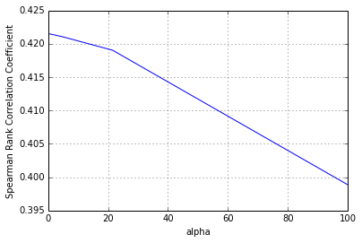

```python
from sklearn import linear_model
from scipy.stats import spearmanr
import numpy.random

# Try a range of alpha values
alphas = np.logspace(-4, 2, 10)

# Use 2 years' data for training starting from Jan 1st 2004
nyears = 2
start = dt.datetime(2004, 1, 1)
end = dt.datetime(2013, 12, 31)
testdays = 7

cors = []
for alpha in alphas:
    cor = []
    trainstart = start
    while trainstart + DateOffset(365*nyears + testdays) < end:
        trainend = trainstart + DateOffset(365*nyears)
        teststart = trainend

        test = setup_test(teststart, testdays)

        train = crimes_grouped[(crimes_grouped['Date'] >= trainstart.date()) &
                               (crimes_grouped['Date'] <= trainend.date())]

        X_train, y_train = split_xy(train)
        y_train = np.log(y_train + 1)

        X_test, y_test = split_xy(test)

        clf = linear_model.Ridge(alpha = alpha)
        clf.fit(X_train, y_train)
        y_pred = np.exp(clf.predict(X_test)) - 1
        cor.append(spearmanr(y_pred, y_test)[0])

        # move the window forward by a random number of days between 15 and 30
        trainstart = trainstart + DateOffset(np.random.random_integers(15, 30, 1)[0])

    cors.append(np.mean(cor))

ridge_models = pd.DataFrame({'alpha': alphas, 'spearmanr': cors})
ridge_models.plot(x = 'alpha', y  ='spearmanr')
plt.ylabel('Spearman Rank Correlation Coefficient')
```

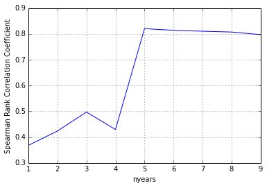

```python
from sklearn.feature_extraction import DictVectorizer
from sklearn import linear_model, grid_search
from scipy.stats import spearmanr
import scipy

start = dt.datetime(2004, 1, 1)
end = dt.datetime(2013, 12, 31)
testdays = 7
cors = []

for nyears in range(1, 10):
    cor = []
    trainstart = start
    while trainstart + DateOffset(365*nyears + testdays) < end:

        trainend = trainstart + DateOffset(365*nyears)
        teststart = trainend + DateOffset(1)

        test = setup_test(teststart, testdays)

        train = crimes_grouped[(crimes_grouped['Date'] >= trainstart.date()) &
                               (crimes_grouped['Date'] <= trainend.date())]


        X_train, y_train = split_xy(train)
        y_train = np.log(y_train + 1)

        X_test, y_test = split_xy(test)

        clf = linear_model.LinearRegression()
        clf.fit(X_train, y_train)
        y_pred = np.exp(clf.predict(X_test)) - 1
        cor.append(spearmanr(y_pred, y_test)[0])

        # move the window forward by a random number of days between 15 and 30
        trainstart = trainstart + DateOffset(np.random.random_integers(15, 30, 1)[0])

    cors.append(np.mean(cor))

linear_models = pd.DataFrame({'nyears': range(1, 10), 'spearmanr': cors})
linear_models.plot(x = 'nyears', y  ='spearmanr')
plt.ylabel('Spearman Rank Correlation Coefficient')
```

### Training and Predicting Crime Occurrence

```python
from sklearn import linear_model
from sklearn.feature_extraction import DictVectorizer
from pandas.tseries.offsets import DateOffset

# Predict crime occurrence for the first week of August 2014
start = dt.datetime(2014, 8, 4)
ndays = 7

# Use the previous five years' data for training
trainstart = dt.datetime(2009, 8, 4)
trainend = dt.datetime(2014, 8, 3)

test = setup_test(start, ndays)

train = crimes_grouped[(crimes_grouped['Date'] >= trainstart.date()) &
                       (crimes_grouped['Date'] <= trainend.date())]

X_train, y_train = split_xy(train)
y_train = np.log(y_train + 1)

X_test, y_test = split_xy(test)

clf = linear_model.LinearRegression()
clf.fit(X_train, y_train)
y_pred = np.exp(clf.predict(X_test)) - 1

test['Predicted'] = y_pred
```

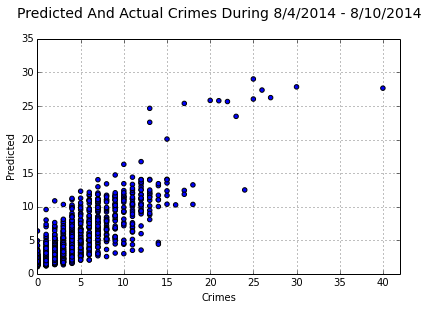

```python
test.plot(x = 'Crimes', y = 'Predicted', kind = 'scatter', figsize = (6.5, 4.5),
          xlim = (0, 42), ylim = (0, 35))
plt.title('Predicted And Actual Crimes During 8/4/2014 - 8/10/2014\n', fontsize = 14)
plt.subplots_adjust(top = 0.85)
plt.savefig('../figs/predict.png')
```

The prediction was based on a linear regression of the following features: the community area, day of week, time of day (each day is divided into three shifts as above), the maximum and minimum temperatures of the day. The data from the previous five-year period (8/4/2009 - 8/3/2014) was used to predict crime occurrence during this particular week. A perfect prediction would have the points lined up along the diagonal line of the plot.

Since I was mainly interested in being able to predict in which community area or shift police officers should be focusing on, I chose Spearman's rank correlation coefficient as the metric for the regression. This measures how well the relationship between two variables can be described using a monotonic function, so that for example, the 10 communities with highest predicted crime would be likely to coincide with the 10 communities that actually have the most crimes committed.

```python
test = pd.merge(test, census[2010][['Total']], left_on = 'Community Area', right_index = True)

total_pop = census[2010]['Total'].sum().astype(float)
num = 10
predicted = []; predicted_pop = []
actual = []; actual_pop = []
random = []; random_pop = []
for d in range(7):
    for s in range(3):
        test_ds = test[(test['Day of Week'] == days[d]) & (test['Shift'] == str(s))]
        total = test_ds['Crimes'].sum().astype(float)
        predicted.append(test_ds.sort('Predicted')[-num:]['Crimes'].sum()/total)
        predicted_pop.append(test_ds.sort('Predicted')[-num:]['Total'].sum()/total_pop)
        actual.append(test_ds.sort('Crimes')[-num:]['Crimes'].sum()/total)
        actual_pop.append(test_ds.sort('Crimes')[-num:]['Total'].sum()/total_pop)
        rand = np.random.random_integers(0, 76, 10)
        random.append(test_ds.iloc[rand]['Crimes'].sum()/total)
        random_pop.append(test_ds.iloc[rand]['Total'].sum()/total_pop)

summary = pd.DataFrame({'Actual Worst 10': actual, 'Predicted Worst 10': predicted, 'Random 10': random})
summary_pop = pd.DataFrame({'Actual': actual_pop, 'Predicted': predicted_pop, 'Random': random_pop})
```

```python
num = 10
predicted_shift = []
actual_shift = []
random_shift = []
for c in range(1, 78):
    test_ds = test[test['Community Area'] == c]
    total = test_ds['Crimes'].sum().astype(float)
    predicted_shift.append(test_ds.sort('Predicted')[-num:]['Crimes'].sum()/total)
    actual_shift.append(test_ds.sort('Crimes')[-num:]['Crimes'].sum()/total)
    rand = np.random.random_integers(0, 20, 10)
    random_shift.append(test_ds.iloc[rand]['Crimes'].sum()/total)

summary_shift = pd.DataFrame({'Actual Worst 10': actual_shift, 'Predicted Worst 10': predicted_shift,
                              'Random 10': random_shift})
```

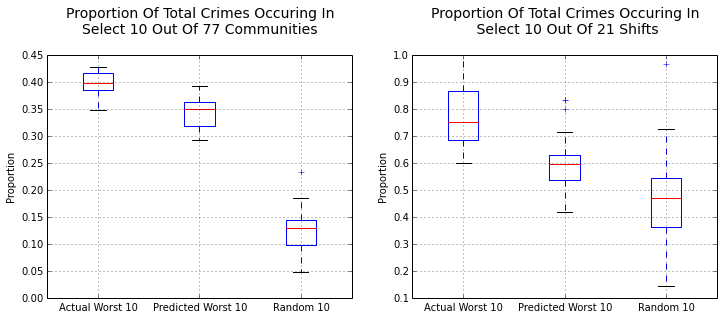

```python
fig = plt.figure(figsize = (12, 5))
ax1 = fig.add_subplot(121)
summary.boxplot(ax = ax1)
ax1.set_ylabel('Proportion')
ax1.set_title('Proportion Of Total Crimes Occuring In\nSelect 10 Out Of 77 Communities\n', fontsize = 14)

ax2 = fig.add_subplot(122)
summary_shift.boxplot(ax = ax2)
ax2.set_ylabel('Proportion')
ax2.set_title('Proportion Of Total Crimes Occuring In\n Select 10 Out Of 21 Shifts\n', fontsize = 14)

plt.subplots_adjust(top = 0.8)
plt.savefig('../figs/summary.png')
```

```python
summary.mean()
```

```
Actual Worst 10       0.397312
Predicted Worst 10    0.343145
Random 10             0.126213
dtype: float64
```

```python
summary_pop.mean()
```

```
Actual       0.205027
Predicted    0.209894
Random       0.137717
dtype: float64
```

The utility of predicting crimes lies in being able to deploy police officers ahead of time so as to maximize their effectiveness. A measure of how well the prediction performs in this sense is shown in the above plots. The figure on the left shows how well the prediction does in allocating police officers to different communities for each 8 hour shift during the week. Let's assume that the strategy is to select 10 out of the 77 communities of Chicago and concentrate all the police efforts upon these 10. For a particular 8 hour shift during the week of Aug. 4th, randomly selecting 10 communities would result in targeting only 12% of the total crimes that were committed during that shift, on average. Selecting the 10 communities with the highest predicted number of crimes results in 34% of the crimes being targeted, while the best-case scenario, when you know ahead of time which 10 communities would have the highest number of crimes committed, would result in 40% of the crimes being targeted, on average.

It is likely that the police officers in one community cannot easily be deployed in another. In this case, the figure on the right shows how best to allocate officers in each community to different shifts. For this scenario, let's assume that the strategy is to concentrate police efforts on 10 out of the 21 shifts during the week. For a particular community area, randomly selecting 10 shifts would target 50% of the total crimes committed during the week in that community area, on average. Selecting the 10 shifts with the highest predicted number of crimes results in 60% of the crimes being targeted, while the best-case scenario, where you know in which 10 shifts the highest number of crimes would be commited ahead of time, would result in 75% of crimes being targeted, on average.

```python
cols = ['DateTime', 'Day of Week', 'Shift', 'Community Area', 'Crimes', 'Predicted']

test[cols].to_csv('../data/result.csv')

# The least crimes occur Tuesday 00 to 08
result1 = test[(test['Day of Week'] == 'Tue') & (test['Shift'] == '0')][cols]
result1.to_csv('../data/result1.csv')

# The most crimes occur Friday 16 to 00
result2 = test[(test['Day of Week'] == 'Fri') & (test['Shift'] == '2')][cols]
result2.to_csv('../data/result2.csv')

# Saturday 08 to 16 has medium crime occurrence
result3 = test[(test['Day of Week'] == 'Sat') & (test['Shift'] == '1')][cols]
result3.to_csv('../data/result3.csv')
```

The crime maps can be seen for Tuesday 00 to 08 (https://jee.cartodb.com/tables/aug_5_2014_tuesday_00_08/map), Friday 16 to 24 (https://jee.cartodb.com/tables/aug_8_2014_friday_16_24/map), and Saturday 08 to 16 (https://jee.cartodb.com/tables/aug_9_2014_saturday_08_16/map)